# Spatial Perturb-Seq Vignette

Kimberle Shen

2024-08-03

#### This package, which builds on a seurat object, provides functions for the analysis and visualization of single-cell spatial perturb-seq data. It includes functionality for annotating barcodes (representing perturbations) which facilites downstream analyses like differential expression, analysis of barcode spatial distribution patterns, and calling cellular neighbours and neighbourhoods for the exploration of cell-cell interactions.

## Adds an image component to a Seurat object

#### Adapted from: https://github.com/STOmics/STCellbin

```r
add_image_slice(obj)
```

```
## An object of class Seurat
## 30280 features across 3757 samples within 2 assays
## Active assay: Spatial (26280 features, 2000 variable features)
##  3 layers present: counts, data, scale.data
##  1 other assay present: BANKSY
##  2 dimensional reductions calculated: spatial, pca
##  1 image present: slice1
```

## Creates a metadata column based on expression of a user-given list of barcodes, with values “Pos” or “Neg”

```r
obj <- annotate_pos_neg(obj, gRNA_list)
```

```
##
##  Neg  Pos
## 3624  133
```

## Creates barplot showing the % of barcode-positive cells in each identity class. Ident can be seurat cluster, or annotated cell type, etc

```
## # A tibble: 2 × 2
##   seurat_clusters Percent_Pos
##   <fct>                 <dbl>
## 1 3                      3.28
## 2 12                     4.43
```

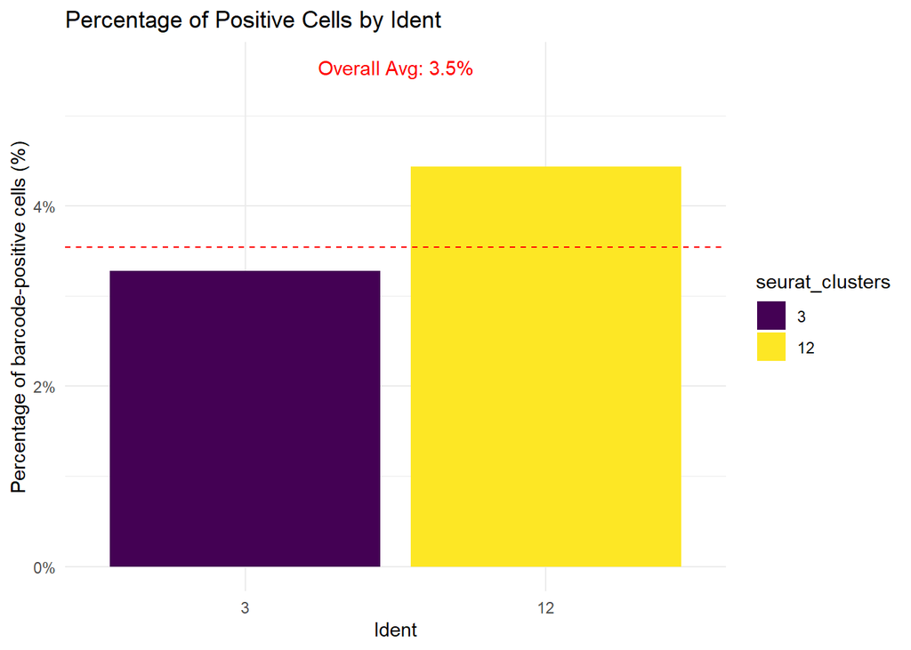

```r
barplot_pos(obj)
```

## Spatial plot of negative and positive cells

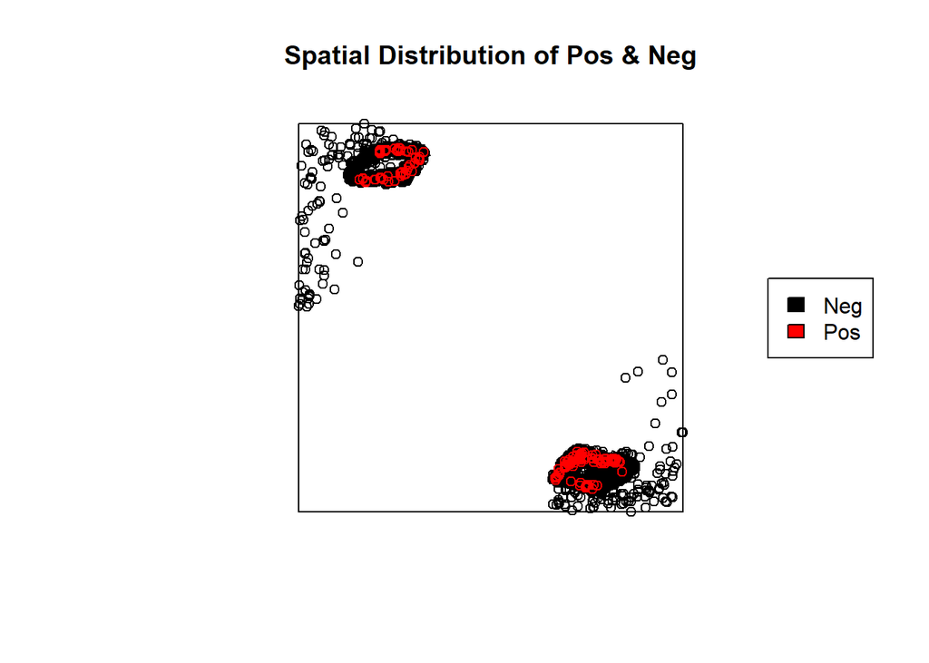

```r
spatial_pos_neg(obj)
```

## Frequency histogram of nearest neighbor distances for Pos points in a spatial region, highlighting distribution of distances

#### A left-skewed graph suggests clustering of Pos points while a right-skewed graph suggests a more dispersed pattern. A uniform graph could indicate random distribution without clustering or dispersion, while multimodal peaks could indicate multiple clusters.

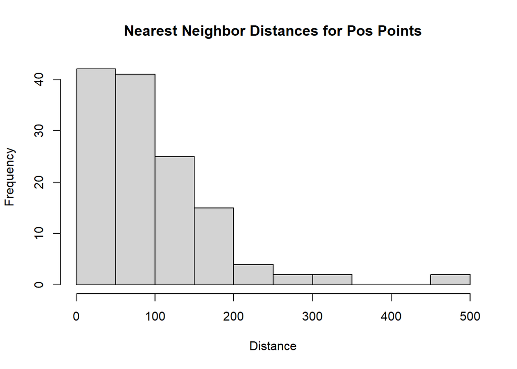

```r
nndist_pos_neg(obj)
```

## Creates a metadata column in a Seurat object based on expression of a list of features, labeling each cell with its barcode, “Neg” or “Multiple”

```r
obj <- annotate_gRNA(obj, gRNA_list)
```

```
##
##      Multiple           Neg sgrna-C9orf72 sgrna-Cfap410     sgrna-clu
##            10          3623             1             6            21
##    sgrna-dpp5    sgrna-fasn    sgrna-flcn    sgrna-gfap   sgrna-lrrk2
##             2            18             3             6             2
##   sgrna-msafe  sgrna-ndufaf  sgrna-oligo2   sgrna-rbfox   sgrna-rraga
##             4             4            13             4             8
##  sgrna-sh3gl2     sgrna-srf   sgrna-stk39    sgrna-tbk1   sgrna-trem2
##             4             2            19             2             5
```

## Creates a piechart showing the proportion of cells having 1, 2, 3 etc unique features

#### In most cases, most cells ideally have only 1 unique barcode

```
##   gRNA_count numCells
## 1          1      124
## 2          2        8
## 3          3        1
```

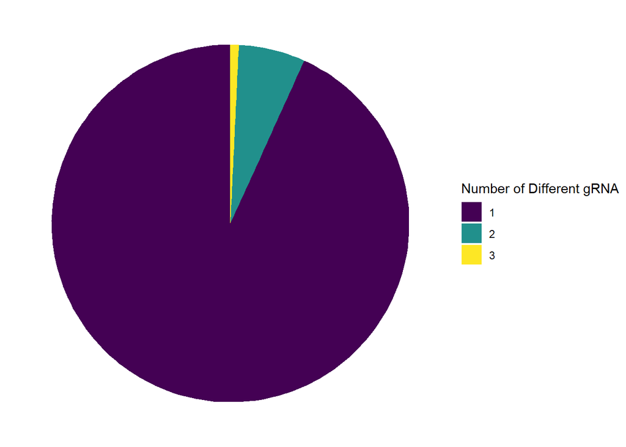

```r
piechart_barcode_uniqueness(obj, gRNA_list)
```

## Bar plot showing the number of cells for each perturbation

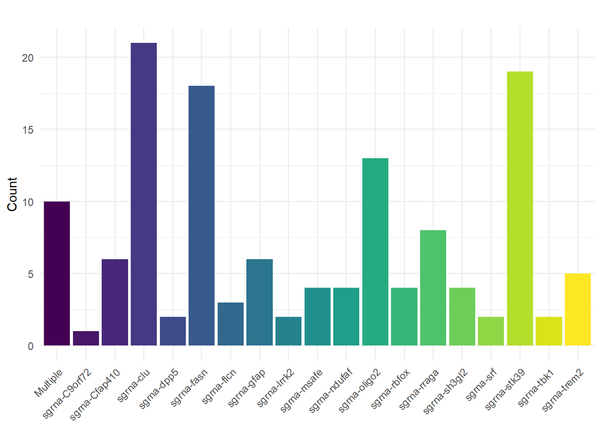

```r
barplot_barcode_count(obj, Multiple = TRUE, Neg = FALSE)
```

## Creates 2 barplots: number of DEGs and average fold change of DEGs, for each perturbation

```
##               numDEG   Avg_FC
## sgrna-oligo2      23 3.348977
## sgrna-rraga       51 4.094054
## sgrna-fasn         5 5.160619
## sgrna-Cfap410     28 4.612094
## sgrna-clu          7 4.051291
## sgrna-gfap        46 3.835338
## sgrna-stk39       13 3.365290
## sgrna-trem2      110 5.649040
```

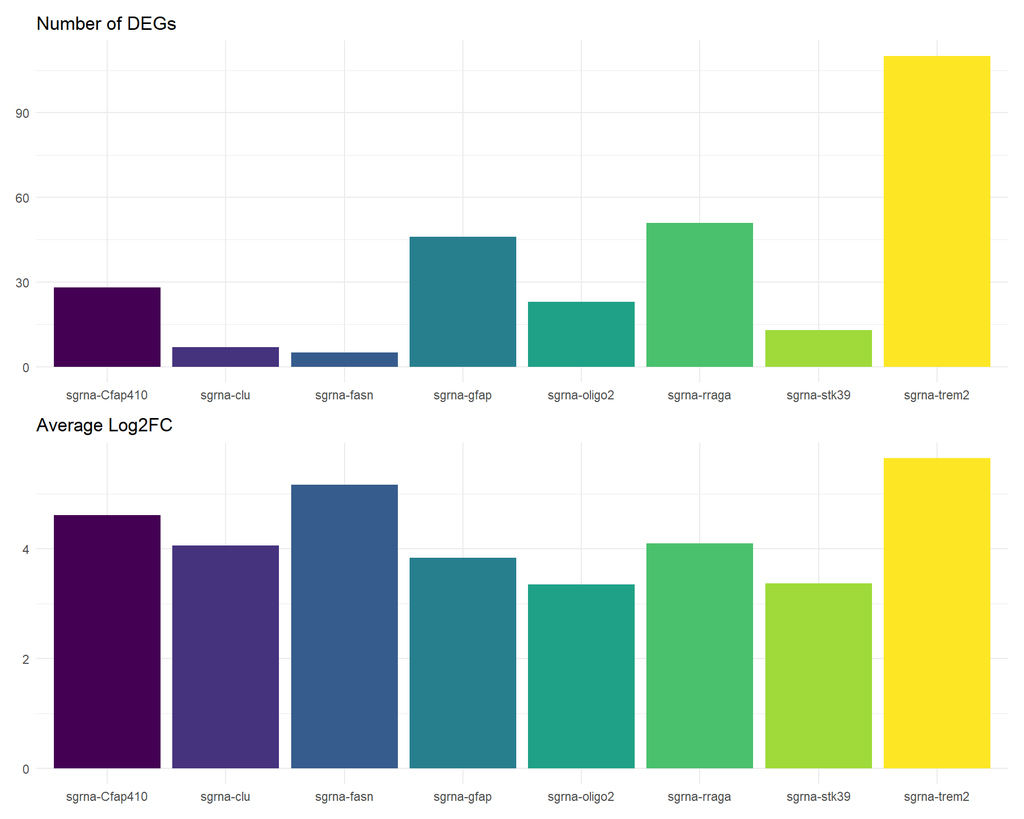

```r
plot_perturbation_effect(obj, perturbations = c("sgrna-oligo2", "sgrna-rraga", "sgrna-fasn", "sgrna-Cfap410", "sgrna-clu", "sgrna-gfap", "sgrna-stk39", "sgrna-trem2"))
```

## Dotplot of upregulated genes for each perturbation

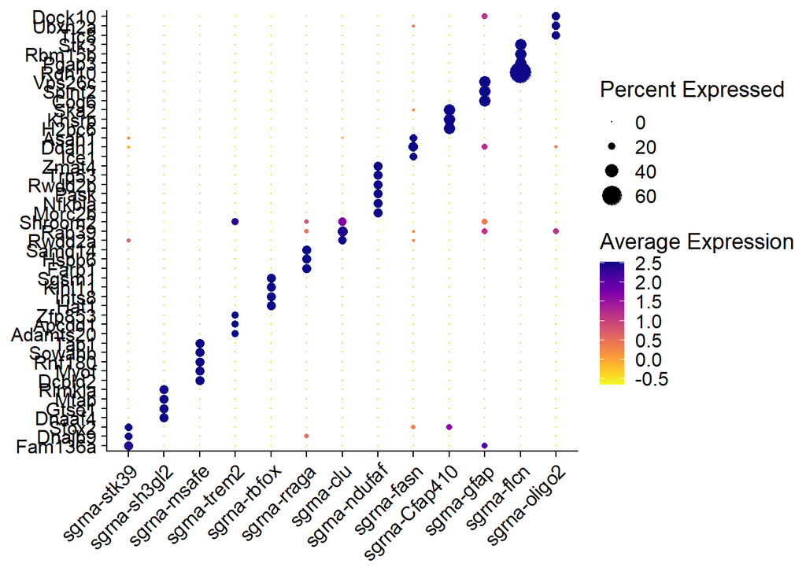

```r
barcodes_to_include <- c("sgrna-Cfap410", "sgrna-clu", "sgrna-fasn", "sgrna-flcn", "sgrna-gfap",
                         "sgrna-msafe", "sgrna-ndufaf", "sgrna-oligo2", "sgrna-rbfox",
                         "sgrna-rraga", "sgrna-sh3gl2", "sgrna-stk39", "sgrna-trem2")

dotplot_upregulated(obj, barcodes_to_include = barcodes_to_include)
```

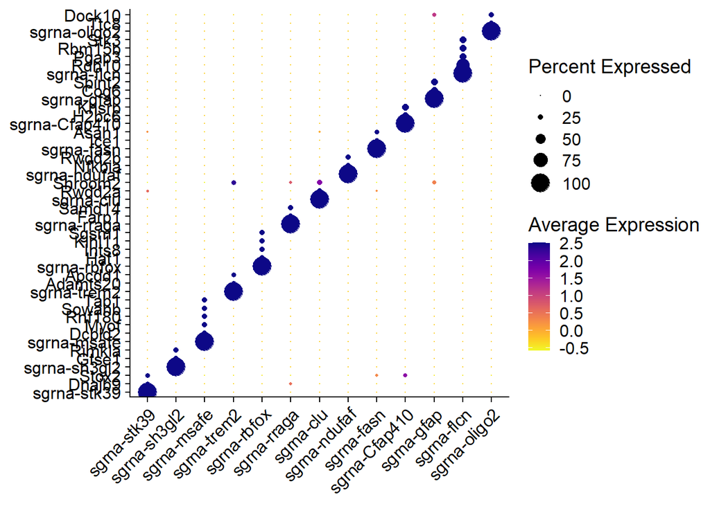

```r
dotplot_upregulated(obj, barcodes_to_include = barcodes_to_include, include_sgrna = TRUE)
```

## Scatterplot showing the spatial location of different perturbations in the tissue

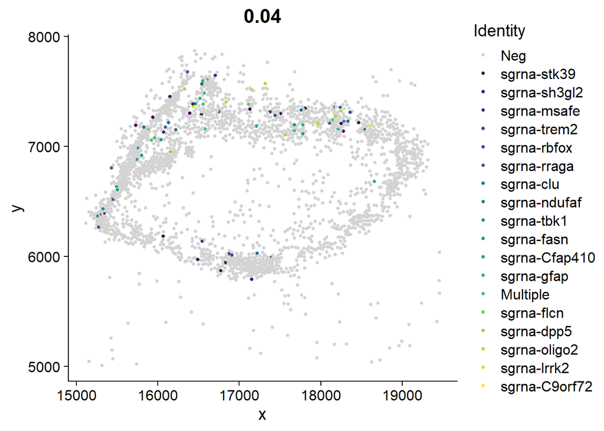

```r
cells <- subset(x = obj, subset = x < 19500 & y > 5000 & x > 15000 & y < 8000)
Idents(cells) <- cells$gRNA
plot_barcode_spread(cells)
```

## Given a list of cellIDs and the Seurat object, returns the cellIDs of its nearest neighbours (euclidean distance)

#### Adapted from: https://cran.rstudio.com/web/packages/RcppHNSW/index.html

```r
cell_list <- c("69243462750838", "82231443856126", "22166326236902", "67598490276766", "81999515620420", "87024627356747", "76965813951447", "32336808792990", "21689584866416")
get_euclidean_neighbours(obj, cell_list = cell_list)
```

```
##   [1] "70403103920949" "67740224197433" "69136088569111" "71111773525255"
##   [5] "66249870546059" "65085934408629" "69836168238731" "67748814132850"
##   [9] "73985106645788" "71008694310656" "70579197581101" "69900592748368"
##  [13] "70257075033928" "71897752540863" "70871255357225" "82106889804524"
##  [17] "82029580393236" "82291573398327" "82201379084991" "82154134444867"
##  [21] "82055350196928" "82544976468712" "81930796145445" "82502026795832"
##  [25] "82433307319111" "81823421963028" "81905026341568" "82613695945522"
##  [29] "82205674052457" "82390357645974" "22286585321211" "22016002381543"
##  [33] "21921513100986" "22449794078397" "22376779634337" "22286585321270"
##  [37] "22522808522538" "22664542443238" "22484153816909" "21582210684620"
##  [41] "22741851854610" "22621592770377" "22793391462124" "21569325782683"
##  [45] "22836341135106" "69243462750838" "66189741004463" "68633577396133"
##  [49] "68002217203654" "68947110008756" "68053756811232" "67306432501739"
##  [53] "81960860914947" "80925773796399" "82617990911432" "79998060860335"
##  [57] "81973745816102" "83558588749347" "79929341384122" "85203561222922"
```

[output cut: 16 more lines]

## Given a list of CellIDs, return CellIDs of K nearest neighbours

#### Adapted from: https://github.com/prabhakarlab/Banksy

```r
cell_list <- c("69243462750838", "82231443856126", "22166326236902", "67598490276766", "81999515620420", "87024627356747", "76965813951447", "32336808792990", "21689584866416")
get_KNN(obj, cell_list)
```

```
## Computing neighbors...
```

```
## Spatial mode is kNN_r
```

```
## Parameters: k_geom=15
```

```
## Done
```

```
## [1] "Number of unique neighbours: 122"
```

```
##   [1] "70403103920949" "67740224197433" "81565723923563" "89008902247666"
##   [5] "82149839477514" "77068893166570" "32345398727559" "21814138917999"
##   [9] "22290880288476" "66361539695565" "81432579937347" "86053964748288"
##  [13] "82291573398292" "77154792512528" "32422708138928" "21522081141861"
##  [17] "22286585321211" "67598490276766" "66314295055388" "81960860914947"
##  [21] "84993107825966" "82334523071214" "77266461662150" "32220844676014"
##  [25] "21547850945603" "22016002381543" "69136088569111" "67160403612942"
##  [29] "80925773796399" "85980950304285" "82240033790689" "76918569311263"
##  [33] "32216549708686" "21921513100370" "22046067152578" "66249870546059"
##  [37] "80406082753475" "85203561222922" "82106889804524" "77129022708628"
##  [41] "32461362844552" "21431886828673" "22144851400371" "71111773525255"
##  [45] "65786014077839" "83421149795616" "89558658061357" "82407537515263"
##  [49] "77283641531398" "32263794348918" "21754009375793" "22222160811699"
##  [53] "69243462750838" "82617990911432" "88085484279420" "82162724379428"
##  [57] "77137612643368" "32422708138857" "21689584866490" "22415434340064"
```

[output cut: 16 more lines]

## Given a list of CellIDs, return CellIDs of neighbours within a certain radius

#### Adapted from: https://cran.rstudio.com/web/packages/RcppHNSW/index.html

```r
cell_list <- c("69243462750838", "82231443856126", "22166326236902", "67598490276766", "81999515620420", "87024627356747", "76965813951447", "32336808792990", "21689584866416")
get_radial_neighbours(obj, cell_list)
```

```
## $`69243462750838`
## character(0)
##
## $`82231443856126`
##  [1] "82390357645974" "82368882809458" "82334523071214" "82257213659788"
##  [5] "82240033790556" "82201379084991" "82106889804524" "82055350196928"
##  [9] "81905026341568" "81879256537716" "81776177322702" "81703162878719"
## [13] "81655918238381" "81505594383020" "81393925233403" "82875688950429"
## [17] "82665235552958" "82544976468712" "82433307319111" "82381767711641"
## [21] "82291573398327" "82205674052457" "82154134444867" "82111184771968"
## [25] "82029580393236" "81930796145445" "81823421963028" "81806242093873"
## [29] "81720342747962" "81621558500134" "81561428958021" "81389630266144"
## [33] "82948703394668" "82691005356890" "82613695945522" "82502026795832"
##
## $`22166326236902`
##  [1] "21968757741125" "21921513100986" "21779779180111" "21582210684620"
##  [5] "21569325782683" "22827751200403" "22793391462124" "22664542443238"
##  [9] "22449794078397" "22376779634337" "22286585321211" "22256520549957"
## [13] "22097606759981" "22016002381543" "22887880742672" "22836341135106"
## [17] "22780506560358" "22741851854610" "22621592770377" "22604412901225"
## [21] "22522808522538" "22484153816909" "22286585321270"
##
## $`67598490276766`
## [1] "67740224197433"
##
## $`81999515620420`
## [1] "81565723923563" "81960860914947"
##
## $`87024627356747`
## character(0)
##
## $`76965813951447`
##  [1] "76519137352671" "76394583301101" "76291504085940" "76261439314806"
##  [5] "76192719838115" "76124000361453" "77799037606884" "77730318130099"
##  [9] "77661598653427" "77575699307355" "77395310681050" "77283641531286"
## [13] "77129022708628" "77068893166570" "76944339115065" "76918569311263"
## [17] "76811195128918" "76690936044673" "76596446764140" "76527727287356"
## [21] "76459007810669" "76416058137686" "76394583301126" "76373108464699"
## [25] "77661598653503" "77378130811999" "77283641531398" "77257871727692"
## [29] "77163382447163" "77137612643368" "76991583755349"
##
## $`32336808792990`
##  [1] "31825707684790" "31748398273491" "31649614025683" "31585189516230"
##  [5] "32723355849691" "32693291078585" "32461362844552" "32422708138857"
##  [9] "32263794348918" "32216549708686" "32083405722535" "31885837226976"
## [13] "33114197873641" "32701881013265" "31898722128901"
##
## $`21689584866416`
##  [1] "21835613754349" "21582210683870" "21380347220939" "22076131922929"
##  [5] "21998822511549" "20882131014719" "21981642642654" "21947282904314"
##  [9] "21921513100370" "21814138917999" "21762599310345" "21689584866490"
## [13] "21659520095444" "21638045258788" "21547850945603" "21517786174466"
## [17] "21444771730680" "21431886828673" "21388937155643" "21333102580931"
## [21] "21324512646236" "21251498202329" "21242908267636" "21187073692744"
## [25] "21118354216184" "21049634739391" "21006685066321" "20920785720512"
## [29] "20920785720428" "22497038718024" "22424024273953" "22393959502932"
## [33] "22144851399730" "22067541988433" "21590800618790" "21483426436389"
## [37] "21294447875351" "21191368660235" "22084721857793"
```

## Frequency plot tabulating the number of positive neighbours each positive cell has

#### The more the number of neighbours (k_geom), the more likely a cell will have positive neighbours

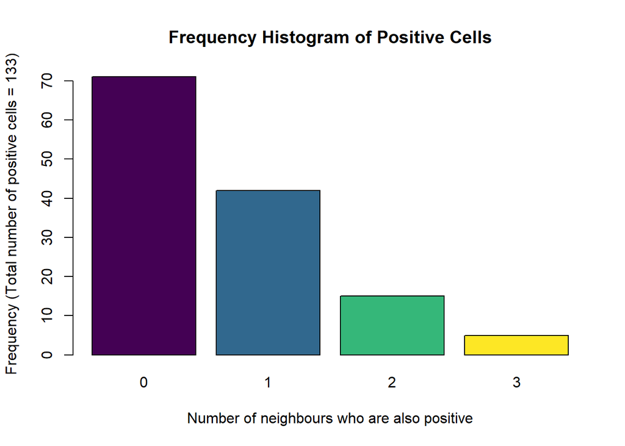

```r
Idents(obj) <- obj$gRNA_exp
cell_list <- WhichCells(obj, ident = "Pos")

positive_neighbor_histogram(obj, cell_list, k_geom = 10)
```

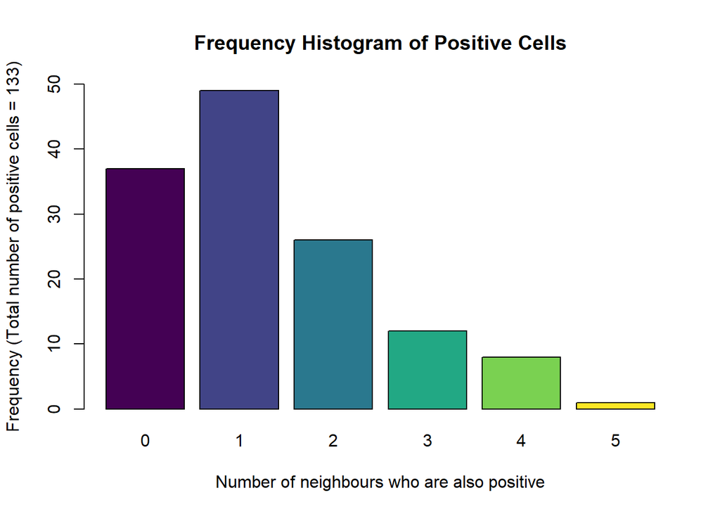

```r
positive_neighbor_histogram(obj, cell_list, k_geom = 20)
```

## VlnPlot showing module score of each perturbation

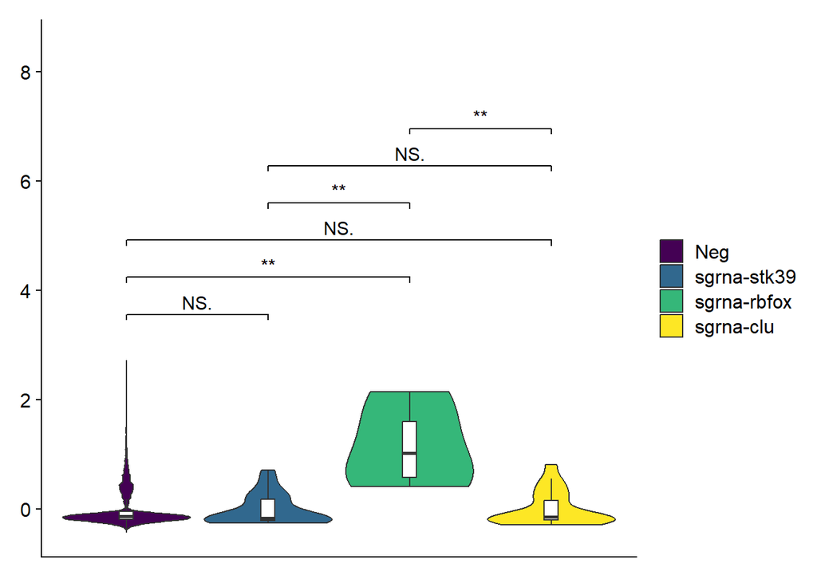

## Interrogates the LIANA database to identify LR interactions, visualizating cell-cell communication between 2 groups of cells (source group and target group)

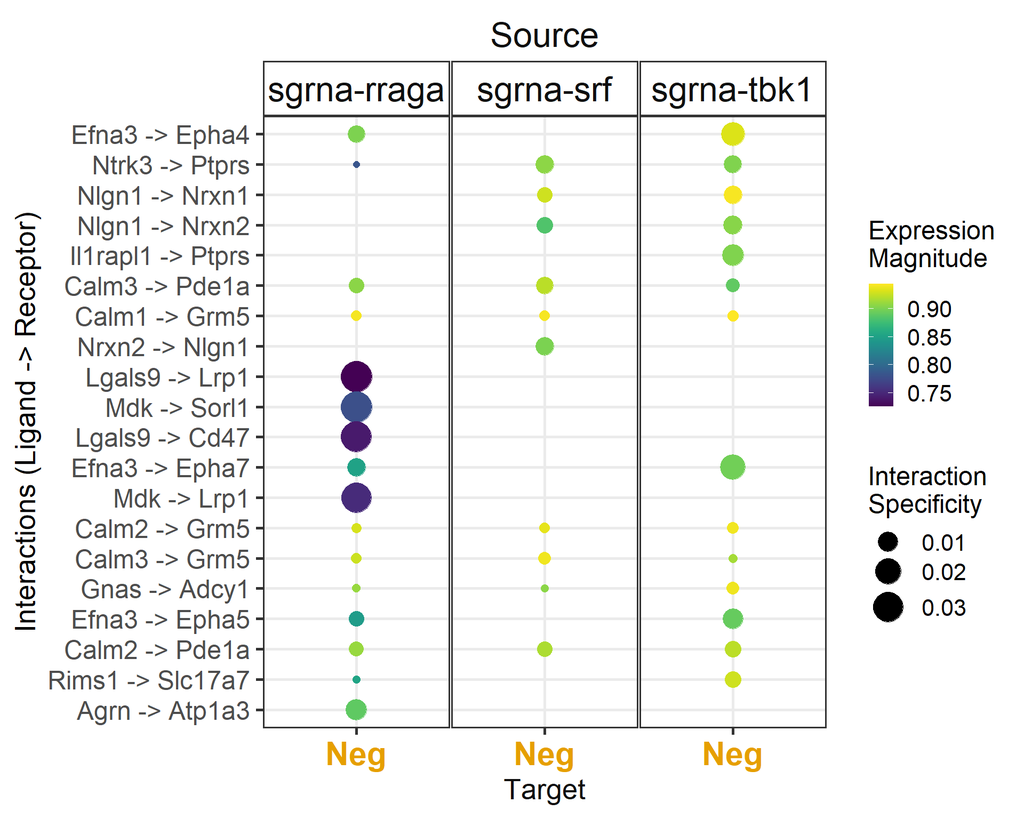

```r
results <- liana_table(obj)

results %>%
  filter(source == "sgrna-srf" | source == "sgrna-tbk1" | source == "sgrna-rraga") %>%
  liana_dotplot(ntop = 20)
```

## To compare at cell-cell communication between Lrrk2-KO cells and mSafe-KO cells and their respective WT neighbours.

#### This takes into account spatial information.

```r
Idents(obj) <- obj$gRNA
cell_list <- WhichCells(object = obj, ident = "sgrna-lrrk2")
neighbours <- get_KNN(obj, cell_list = cell_list)
```

```
## [1] "Number of unique neighbours: 30"
```

```r
cell_list <- c(cell_list, neighbours)
obj_selected <- subset(obj, cells = cell_list)
results1 <- liana_table(obj_selected)

cell_list <- WhichCells(object = obj, ident = "sgrna-msafe")
neighbours <- get_KNN(obj, cell_list = cell_list)
```

```
## [1] "Number of unique neighbours: 60"
```

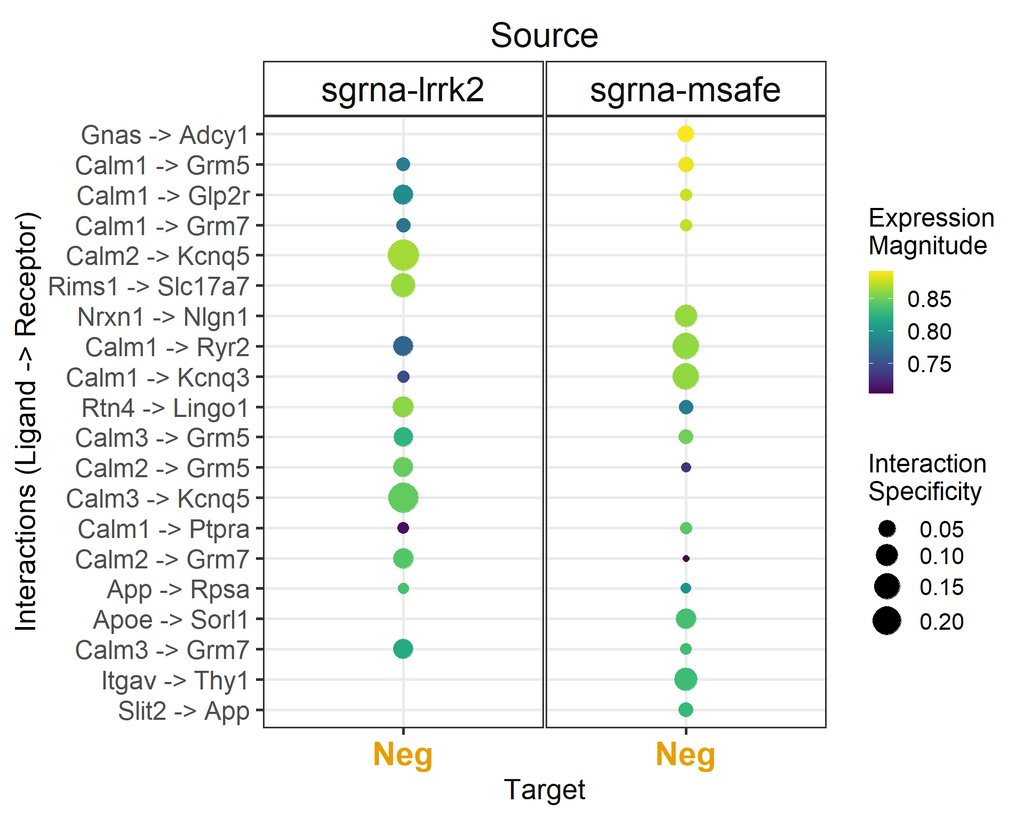

```r
cell_list <- c(cell_list, neighbours)
obj_selected <- subset(obj, cells = cell_list)
results2 <- liana_table(obj_selected)

results <- rbind(results1, results2)

results %>%
  arrange(desc(sca.LRscore)) %>%
  filter(source == "sgrna-lrrk2" | source == "sgrna-msafe") %>%
  liana_dotplot(ntop = 20)
```

## Plot of each cell and their neighbours, with each cell coloured by expression level of a specified ligand/receptor pair

```r
cell_list_source = c("70596377451715", "69020124453852") # top and bottom
cell_list_target = get_KNN(obj, cell_list_source)
```

```
## [1] "Number of unique neighbours: 30"
```

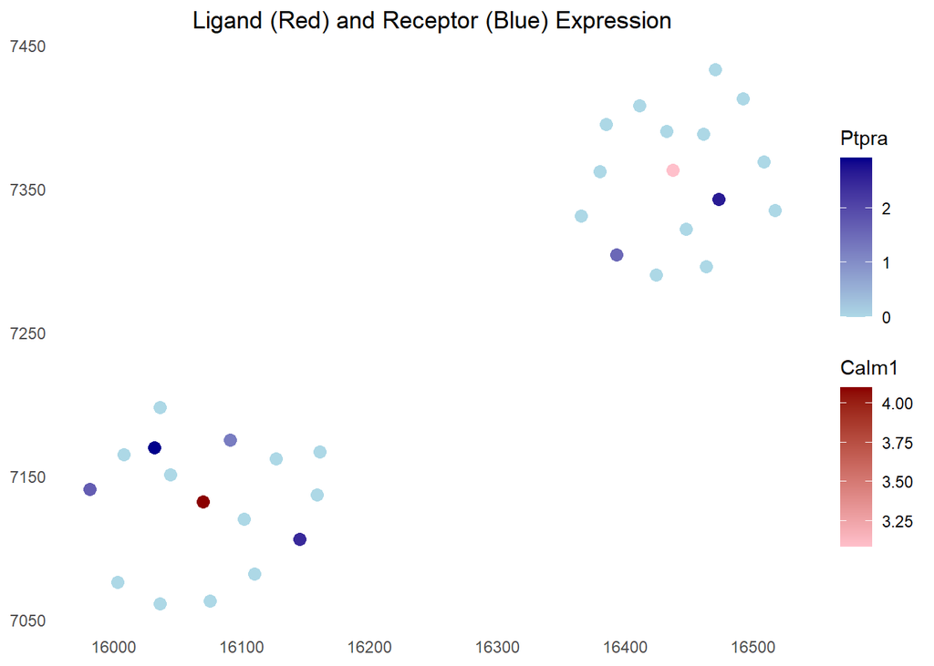

```r
plot_ligand_receptor(obj, cell_list_source, cell_list_target, ligand = "Calm1", receptor = "Ptpra")
```

## Estimating power based on a gamma fit model in a scRNA-seq dataset to determine the ability to detect true DE, using scPower.

```r
power_estimation(obj, perturbation = "sgrna-clu", control = "sgrna-msafe", nSamples = 10)
```

```
## [1] "The power is estimated to be 0.651017159753292. A power of 0.8 is generally accepted to be sufficient."
```

```r
power_estimation(obj, perturbation = "sgrna-clu", control = "sgrna-msafe", nSamples = 20)
```

```
## [1] "The power is estimated to be 0.861902591224339. A power of 0.8 is generally accepted to be sufficient."
```

```r
end_time <- Sys.time()
print(paste0("Vignette runtime (min): ", as.numeric(difftime(end_time, start_time, units = "mins"))))
```

```
## [1] "Vignette runtime (min): 3.205151450634"
```